# Frequency of Steps per Interval

Daniel Flick

May 10, 2017

## Step 1 in Analysis

Finally, we graph the mean number of steps taken during each 5 minute interval (across all users) and determine the 5 minute interval associated with the maximum average number of steps.

```r
library(lubridate)
library(dplyr)
```

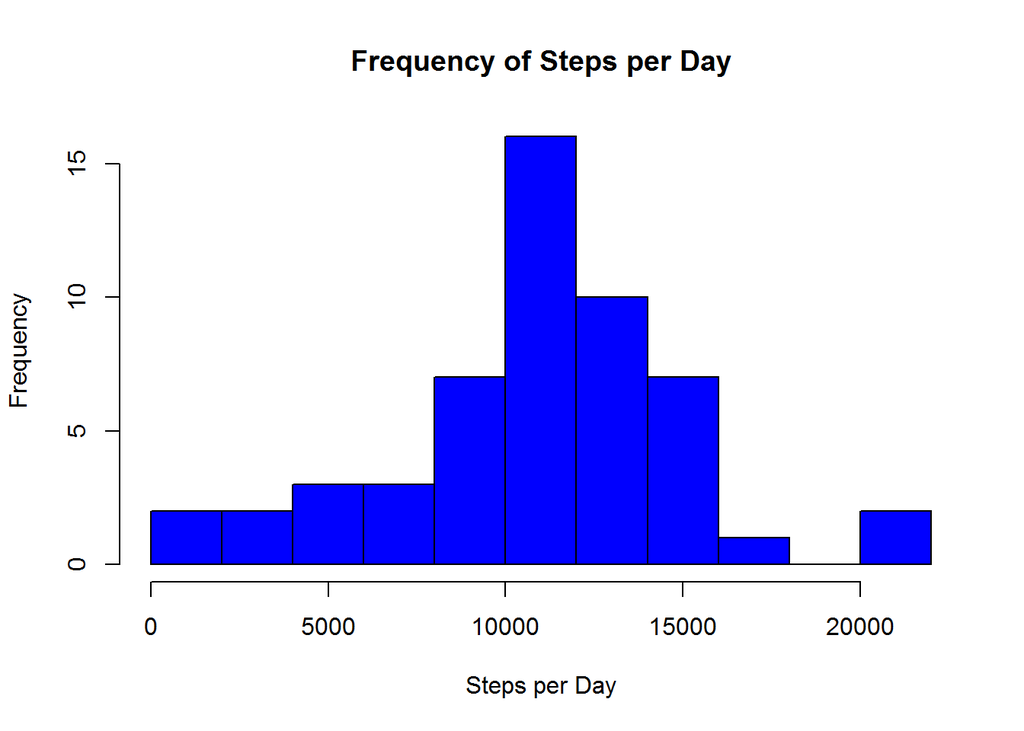

```r
setwd("C:/Users/djflick/My Documents/R Programming Assignments/Rep_Research")

data<-read.csv("activity.csv",header=T,stringsAsFactors=F)

data$datej<-julian(as.Date(data$date))

data.nona<-data[!is.na(data$steps),]

steps.day<-group_by(data.nona,datej)
data.sumbyday<-summarize(steps.day,total.steps=sum(steps))

hist(data.sumbyday$total.steps, breaks=10, col="blue", xlab="Steps per Day", main="Frequency of Steps per Day")
```

```r
#Calculate the mean and median number of steps per day
mean.steps<-mean(data.sumbyday$total.steps)
median.steps<-median(data.sumbyday$total.steps)

# Print the mean and median steps per day
print(paste("Mean steps per day is ", mean.steps))
```

```
## [1] "Mean steps per day is  10766.1886792453"
```

```r
print(paste("Median steps per day is ",median.steps))
```

```
## [1] "Median steps per day is  10765"
```

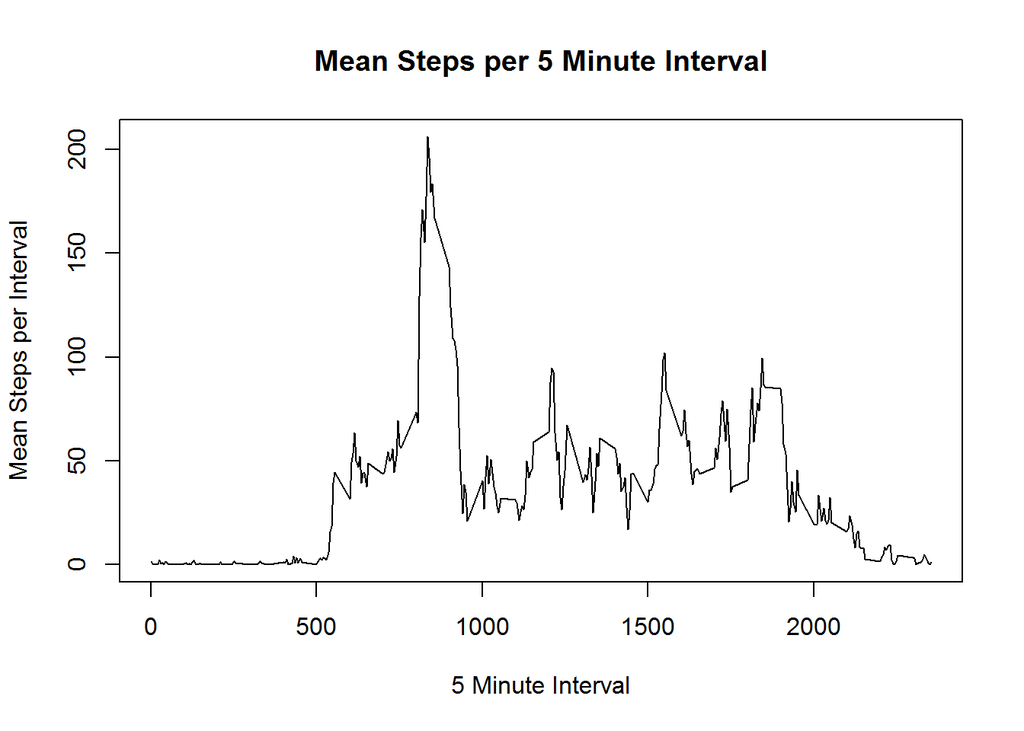

```r
#Calculate the number of steps in each interval - and the avg steps per interval - then plot
steps.interval<-group_by(data.nona,interval)
avginterval<-summarize(steps.interval,meansteps.interval=mean(steps))

plot(avginterval$interval,avginterval$meansteps.interval,type='l',xlab="5 Minute Interval",
     ylab="Mean Steps per Interval",main="Mean Steps per 5 Minute Interval")
```

```r
#Find the interval with the highest mean number of steps across all days
index.high<-which(avginterval$meansteps.interval==max(avginterval$meansteps.interval))
print(paste("5 Minute Interval associated with max number of steps per day is Interval",avginterval[index.high,1]))
```

```
## [1] "5 Minute Interval associated with max number of steps per day is Interval 835"
```

## Step 2 in Analysis

In step 2, we first determine the number of observations in the original data set that contain incomplete data. For each missing value (of the STEPS variable), we impute a step value equal to the average number of steps associated with the associated interval (across all non-missing values). We then draw a histogram of the frequency of steps, using this updated data set. We note that there is no difference in the mean number of steps using this updated data set (compared to the original). The MEDIAN of this updated data set is only slightly different than the original data set’s MEDIAN number of steps.

```r
print(paste("The number of rows that do not contain complete data is ",sum(!complete.cases(data))))
```

```
## [1] "The number of rows that do not contain complete data is  2304"
```

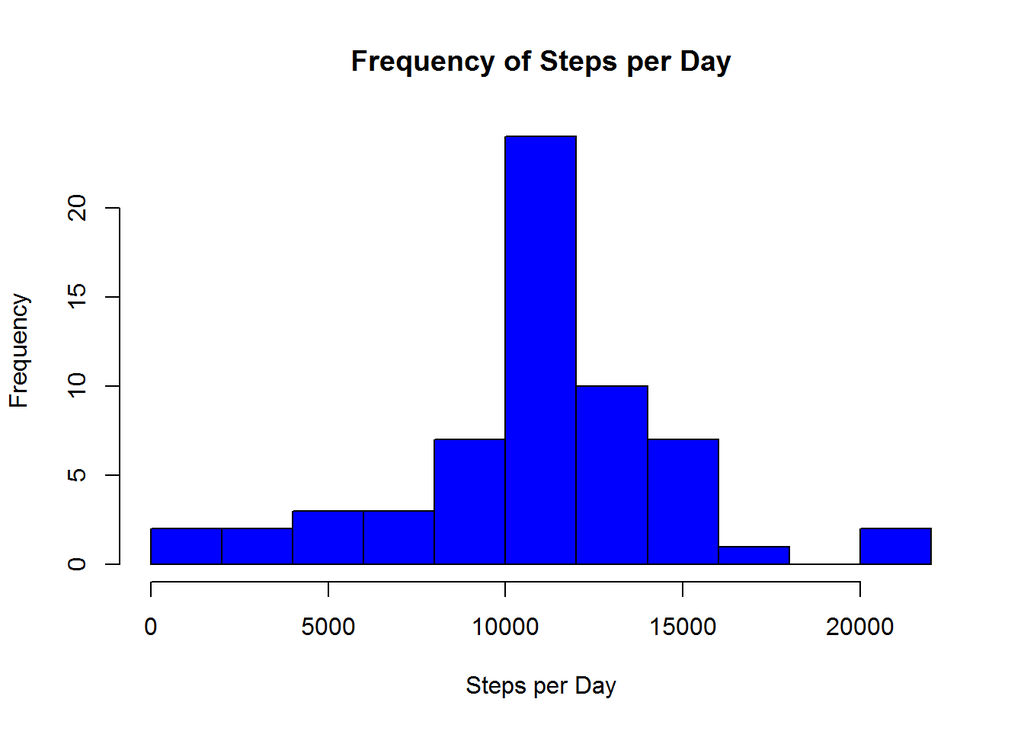

```r
data.new<-data

for (i in 1:nrow(data))
 {      ifelse (is.na(data[i,1]),
        data.new[i,1]<-avginterval[as.integer(which(avginterval$interval==data[i,3])),2],
        data.new[i,1]<-data[i,1])
 }


#Calculate the number of steps by day, using the data set with imputed values
steps.day<-group_by(data.new,datej)
data.sumbyday<-summarize(steps.day,total.steps=sum(steps))

#Draw histogram of total steps taken per day

hist(data.sumbyday$total.steps, breaks=10, col="blue", xlab="Steps per Day", main="Frequency of Steps per Day")
```

```r
#Calculate the mean and median number of steps per day
mean.steps<-mean(data.sumbyday$total.steps)
median.steps<-median(data.sumbyday$total.steps)

# Print the mean and median steps per day
print(paste("Mean steps per day is ", mean.steps))
```

```
## [1] "Mean steps per day is  10766.1886792453"
```

```r
print(paste("Median steps per day is ",median.steps))
```

```
## [1] "Median steps per day is  10766.1886792453"
```

## Step 3 in Analysis

Finally, we compare the average number of steps taken across each interval during the weekends and weekdays. The final chart shows the averages for the two, plotted against each other.

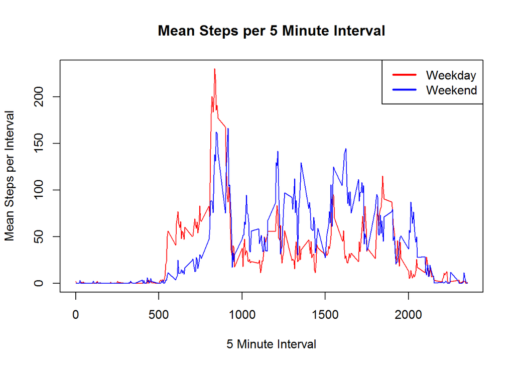

```r
data.new$wkday<-weekdays(as.Date(data.new$date))

data.new$wkday<-ifelse (data.new$wkday=="Saturday" | data.new$wkday=="Sunday","Weekend", "Weekday")

data.new$wkday<-as.factor(data.new$wkday)

datanew.day<-data.new[data.new$wkday=="Weekday",]
datanew.end<-data.new[data.new$wkday=="Weekend",]


steps.dayinterval<-group_by(datanew.day,interval)
steps.endinterval<-group_by(datanew.end,interval)


avgintervalday<-summarize(steps.dayinterval,meansteps.dayinterval=mean(steps))
avgintervalend<-summarize(steps.endinterval,meansteps.endinterval=mean(steps))


plot(avgintervalday$interval,avgintervalday$meansteps.dayinterval,type='l',xlab="5 Minute Interval",
     ylab="Mean Steps per Interval",main="Mean Steps per 5 Minute Interval",col="red")


lines(avgintervalend$interval,avgintervalend$meansteps.endinterval,type='l',col="blue")
legend("topright",c("Weekday","Weekend"),lwd=c(2.5,2.5),col=c("red","blue"))
```